# Homework #2

## The Data

There is 1000 observations, spread across 10 csv files in a zip.

1. First you will need to use `unzip` to unzip it.
2. Next, you will need to generate a vector of all of those files with `list.files`. It works like this:

```r
library(stringr)
library(reshape2)
library(ggplot2)
file_list <- list.files("~/Desktop/DataWrangling/homework2/data/", pattern = ".csv",
                        all.files = TRUE, full.names = TRUE)
df_list <- lapply(file_list, read.csv)

better_df <- do.call(rbind, df_list)
```

3. You can use a `for loop`, an `lapply`, or a `purrr::map` statement to bring all of those files together into one data frame. The columns are in the same order, so feel free to bind them together. If you end up with a list of data frames, you can use `do.call(rbind, your_object)`, `dplyr::bind_rows`, or `data.table::rbindlist` to bring them together.

## Data Prep Tasks

This part should live in a separate qmd file.

1. Create a function to clean ratings & length variables.
2. Create a total length (as in movie length) column.
3. Create a date delta between release time and review time.
4. Pick a word from the reviews and count how many times that word appears.
5. Create an aggregated data set for the unique movies. There should be movies, average ratings, release year, genre, and total number of reviews.
6. You should have two data frames, so `save` those objects for the next step.

## Analytic Tasks

The tasks below should live in a separate qmd from your prep work. You will want to `load` your data from the previous step.

```r
# load Data Prep
load("homework_2_data.Rdata")
# better_df
# even_better_df
```

1. Which genre has the highest critic rating? Viewer rating?

```r
# Create data frame based on genre & critic rating & viewer rating from better_df
agg_rating_maybe <- aggregate(avg_rating ~ reviewer_type + genre,
                              FUN = mean,
                              data = better_df)

# Go from long data frame to wide data frame, use dcast to widen data frame
widen_agg_rating <- dcast(data = agg_rating_maybe,
                          formula = genre ~ reviewer_type,
                          value.var = "avg_rating")

# Find the highest rating of each reviewer type

# Comedy has the highest average critic rating
widen_agg_rating[which.max(widen_agg_rating$Critic), ]
```

```
   genre Critic   Viewer
2 Comedy 2.9925 3.547973
```

```r
# Drama has the highest average viewer rating
widen_agg_rating[which.max(widen_agg_rating$Viewer), ]
```

```
  genre   Critic  Viewer
3 Drama 2.866463 3.55367
```

The genre with the highest critic rating is Comedy, while Drama has the highest viewer rating.

2. What is the relationship between movie length and average rating?

```r
# Movie length is different for movies in the data provided,
# decided to average the total length in minutes
better_df[better_df$title == 'A Glimpse Through Time', ]
```

```
                     title age children_in_home             education gender
134 A Glimpse Through Time  42                3 Completed High School female
181 A Glimpse Through Time  47                1     Completed College female
328 A Glimpse Through Time  48                1     Completed College female
481 A Glimpse Through Time  36                1         Post-Graduate female
554 A Glimpse Through Time  35                1         Post-Graduate   male
678 A Glimpse Through Time  30                0         Post-Graduate female
684 A Glimpse Through Time  47                1 Completed High School   male
796 A Glimpse Through Time  63                1     Completed College female
832 A Glimpse Through Time  37                1 Completed High School female
    reviewer_type work_status genre length_minutes season total_reviews
134        Viewer    Employed Other             48   Fall          8842
181        Viewer    Employed Other              8   Fall          8842
328        Viewer    Employed Other             45   Fall          8842
481        Viewer    Employed Other             25   Fall          8842
```

[output cut: 35 more lines]

```r
# Create separate data frames based on movie length & average rating, then merge together
# aggregate
agg_movie_rating <- aggregate(avg_rating ~ title,
                                     FUN = mean,
                                     data = better_df)
agg_movie_length <- aggregate(total_length ~ title,
                                     FUN = mean,
                                     data = better_df)
# merge two aggregations together
movie_rating_length <- merge(x = agg_movie_length,
                              y = agg_movie_rating,
                              by = 'title')

# Find the correlation between movie length & avg_rating
cor(movie_rating_length$avg_rating, movie_rating_length$total_length)
```

```
[1] -0.04987857
```

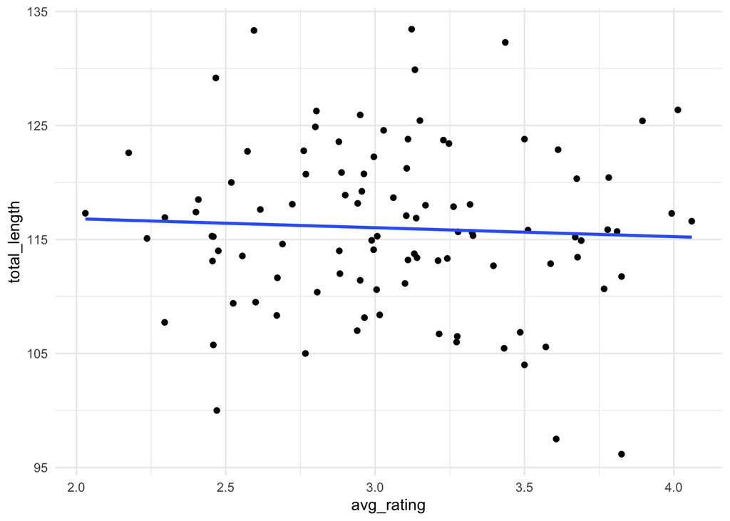

```r
# Correlation = -0.04958
# Very low correlation

# plot the movie length & avg_rating to visualize relationship
ggplot(movie_rating_length, aes(avg_rating, total_length)) +
  geom_point() +
  geom_smooth(method = 'lm', se = FALSE) +
  theme_minimal()
```

The relationship between the total length of a movie and the average rating is weak. This shows that the total length of a movie does not necessarily contribute to the average rating.

3. What is the relationship between the date delta and average rating?

```r
# Aggregate date_diff by title from better_df
date_agg_relationship <- aggregate(date_diff ~ title,
                                      FUN = mean,
                                      data = better_df)

# merge aggregation & avg_rating from even_better_df
rating_date_dif_relationship <- merge(x = date_agg_relationship,
                                      y = even_better_df,
                                      by = 'title')

# Checking to make sure mean of date diff was calculated correctly
mean(better_df$date_diff[better_df$title == 'A Glimpse Through Time'])
```

```
[1] 1845.556
```

```r
# Find correlation of avg_rating & date_diff
cor(rating_date_dif_relationship$avg_rating, rating_date_dif_relationship$date_diff)
```

```
[1] -0.2419758
```

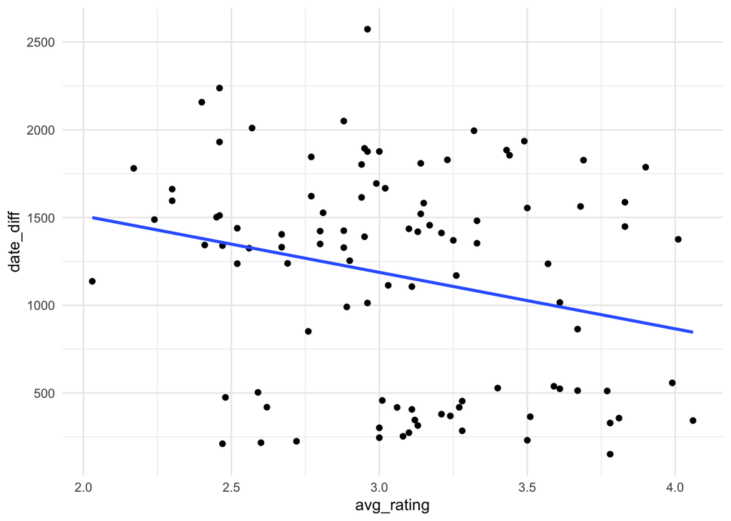

```r
# correlation = -0.242

# ggplot relationship
ggplot(rating_date_dif_relationship, aes(avg_rating, date_diff)) +
  geom_point() +
  geom_smooth(method = 'lm', se = FALSE) +
  theme_minimal()
```

The correlation between average rating and date delta is higher than the length of a movie and the average rating but is still overall a weak relationship. This suggests that the average rating is not affected by the date difference of review date and the movie release date.

4. What is the relationship between total number of reviews and average?

```r
str(even_better_df)
```

```
'data.frame':   100 obs. of  5 variables:
 $ title        : chr  "A Glimpse Through Time" "Adventures of the Little Ones" "Amour Forever" "Beneath the Surface" ...
 $ avg_rating   : num  2.77 3.23 2.99 3.69 3.01 2.8 2.94 3.33 2.69 2.45 ...
 $ total_reviews: chr  "8842" "8607" "6251" "9202" ...
 $ release_date : chr  "1989" "1997" "2004" "2011" ...
 $ genre        : chr  "Other" "Kids" "Romance" "Drama" ...
```

```r
# convert total reviews to numeric
even_better_df$total_reviews <- as.numeric(even_better_df$total_reviews)

# Find correlation of total number of reviews & average rating
cor(even_better_df$avg_rating, even_better_df$total_reviews)
```

```
[1] 0.4748203
```

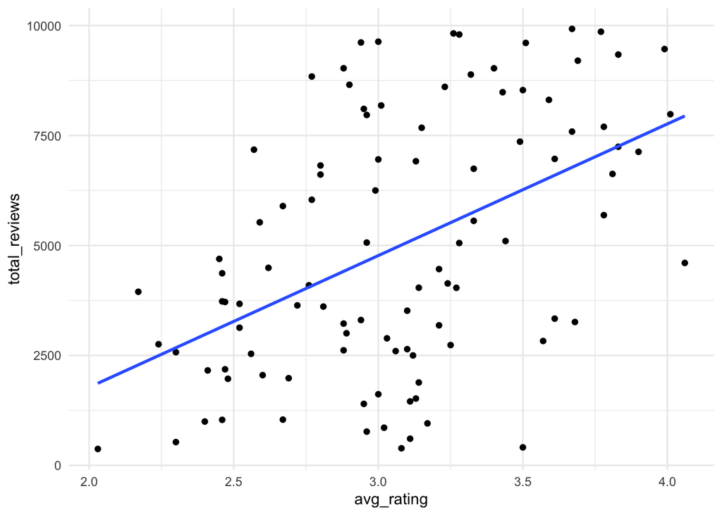

```r
# correlation = 0.475

# Use ggplot to visualize the relationship
ggplot(even_better_df, aes(avg_rating, total_reviews)) +
  geom_point() +
  geom_smooth(method = 'lm', se = FALSE) +
  theme_minimal()
```

The relationship between the total number of reviews and average rating has a positive correlation of 0.475. This suggests, that the more reviews a movie has the average rating is more likely to increase.

4. Which movie contains your word of interest at the highest frequency. Does that word have any relationship with average rating?

```r
# aggregate disaster by title.
# To add the count of disaster not the mean, use the sum function
agg_disaster <- aggregate(disaster ~ title,
                          data = better_df,
                          FUN = sum)

# merge aggregation for avg_rating & disaster count by title
merge_disaster <- merge(x = agg_disaster,
                      y = even_better_df,
                      by = 'title')

# sort/order the count of disaster
merge_disaster <- merge_disaster[order(merge_disaster$disaster, decreasing = TRUE), ]
merge_disaster[1:2, ]
```

```
                title disaster avg_rating total_reviews release_date
6  Beyond the Horizon        3       2.80          6820         2010
83     Sweet Serenade        3       2.46          3730         1996
              genre
6  Action/Adventure
83          Romance
```

```r
# Beyond the Horizon and Sweet Serenade both have the highest frequency of 'disaster' in the review text.

# Find relationship between avg_rating & 'disaster'
cor(merge_disaster$avg_rating, merge_disaster$disaster)
```

```
[1] -0.3997023
```

```r
# correlation is -0.3997

# Make a linear model of avg_rating and disaster to understand relationship.
lm1 <- lm(avg_rating ~ disaster, data = merge_disaster)
summary(lm1)
```

```
Call:
lm(formula = avg_rating ~ disaster, data = merge_disaster)

Residuals:
     Min       1Q   Median       3Q      Max
-1.12729 -0.22732 -0.02229  0.29521  0.90271

Coefficients:
            Estimate Std. Error t value Pr(>|t|)
(Intercept)  3.15729    0.04763  66.290  < 2e-16 ***
disaster    -0.26996    0.06254  -4.317 3.79e-05 ***
---
Signif. codes:  0 '***' 0.001 '**' 0.01 '*' 0.05 '.' 0.1 ' ' 1

Residual standard error: 0.4262 on 98 degrees of freedom
Multiple R-squared:  0.1598,    Adjusted R-squared:  0.1512
F-statistic: 18.63 on 1 and 98 DF,  p-value: 3.791e-05
```